# Differential Protein Expression Analysis

## 4.2 DEP Analysis for bert_vs_tn

```r
data_diff2a <- test_diff(data_se_norm_imp2a, type = "control", control = "WT")
dep2a <- add_rejections(data_diff2a, alpha = 0.05, lfc = 1)
```

### 4.2.1 Heatmap for bert_vs_tn analysis

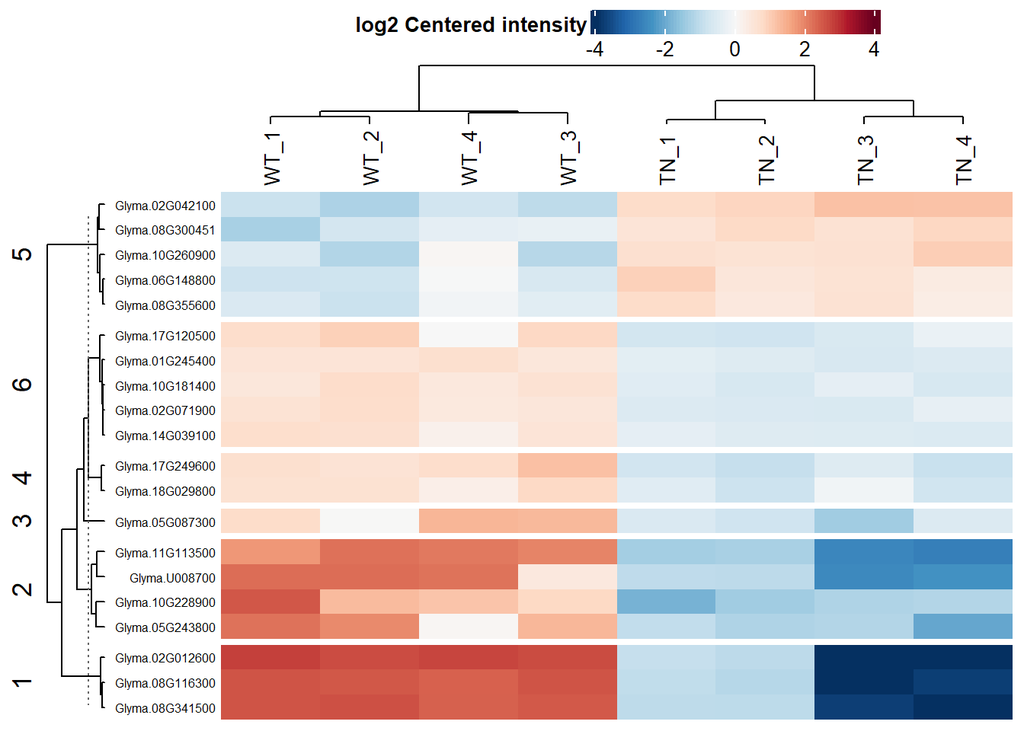

```r
plot_heatmap(dep2a, type = "centered", kmeans = TRUE, k = 6, col_limit = 4)
```

### 4.2.2 PCA plot for bert_vs_tn analysis

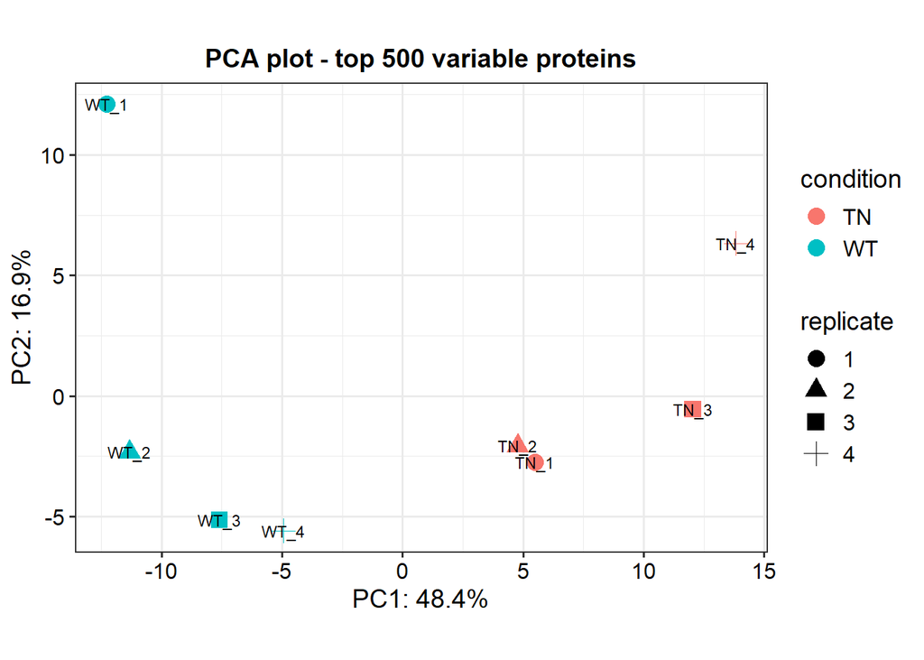

```r
plot_pca(dep2a, x = 1, y = 2, label = TRUE, n = 500)
```

## 4.3 DEP Analysis for bert_vs_tn1 and bert_vs_tn2

```r
data_diff2b <- test_diff(data_se_norm_imp2b, type = "control", control = "WT")
dep2b <- add_rejections(data_diff2b, alpha = 0.05, lfc = 1)
```

### 4.3.1 Heatmap for bert_vs_tn analysis II

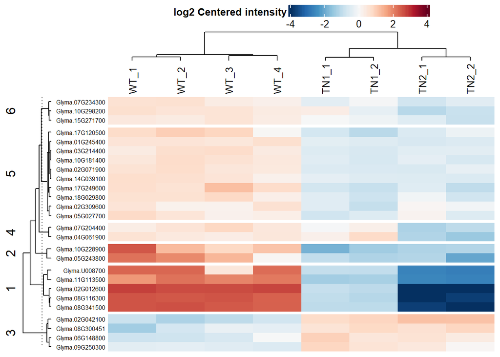

```r
plot_heatmap(dep2b, type = "centered", kmeans = TRUE, k = 6, col_limit = 4)
```

### 4.3.2 PCA plot for bert_vs_tn analysis II

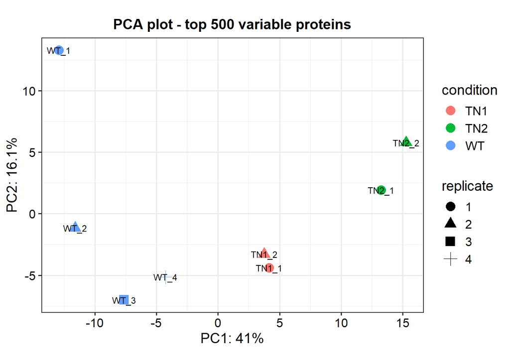

```r
plot_pca(dep2b, x = 1, y = 2, label = TRUE, n = 500)
```

# 5 Results

## 5.1 Comparative Analysis of DEP Results

### 5.1.1 Volcano plot for MO_vs_TNB analysis

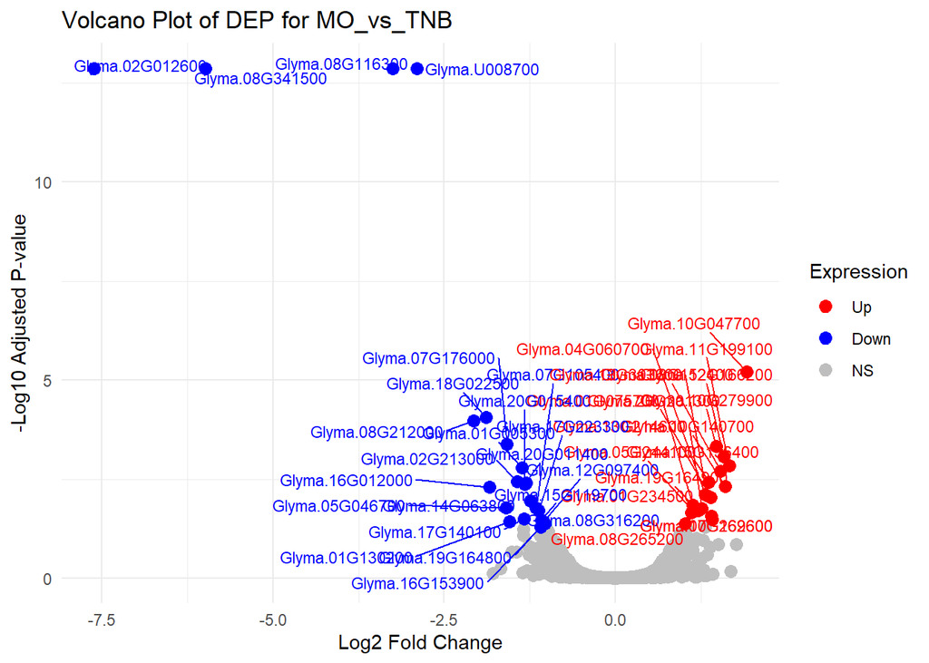

```r
#pVol <- plot_volcano(dep, contrast='Mutant_vs_Control', label_size=2, adjusted=TRUE, add_names=TRUE)

pVol <- plot_volcano(dep1, contrast='Mutant_vs_Control', label_size=2, adjusted=TRUE, add_names=TRUE)

# Extract data from the plot object
volcano_data <- pVol$data

# Add a new column for DE categories based on x and significance
volcano_data$DE <- with(volcano_data,
                        ifelse(significant & x > 0, "Up",
                               ifelse(significant & x < 0, "Down", "NS"))
)

# Convert DE column to a factor for consistent plotting
volcano_data$DE <- factor(volcano_data$DE, levels = c("Up", "Down", "NS"))

# Create the volcano plot with new DE column
pVol <- ggplot(volcano_data, aes(x = x, y = y, color = DE)) +
  geom_point(size = 3) +
  scale_color_manual(
    values = c(
      "Up" = "red",         # Upregulated proteins
      "Down" = "blue",      # Downregulated proteins
      "NS" = "gray"         # Non-significant proteins
    )
  ) +
  geom_text_repel(
    aes(label = ifelse(DE != "NS", name, "")), # Label significant points (Up or Down)
    max.overlaps = 50,
    size = 3
  ) +
  theme_minimal() +
  labs(
    title = "Volcano Plot of DEP for MO_vs_TNB",
    x = "Log2 Fold Change",
    y = "-Log10 Adjusted P-value",
    color = "Expression"
  )

# Display the volcano plot
print(pVol)
```

```r
# Save the customized plot

ggsave("prtnquant-volcanoplot_V2_MO_vs_TNB.png", plot = pVol, width = 10, height = 8)
```

#### 5.1.1.1 Mutant Proteins LE (Glyma.02G012600), KTi3 (Glyma.08G341500), and P34 (Glyma.08G116300) genes in MO_vs_TNB comparison

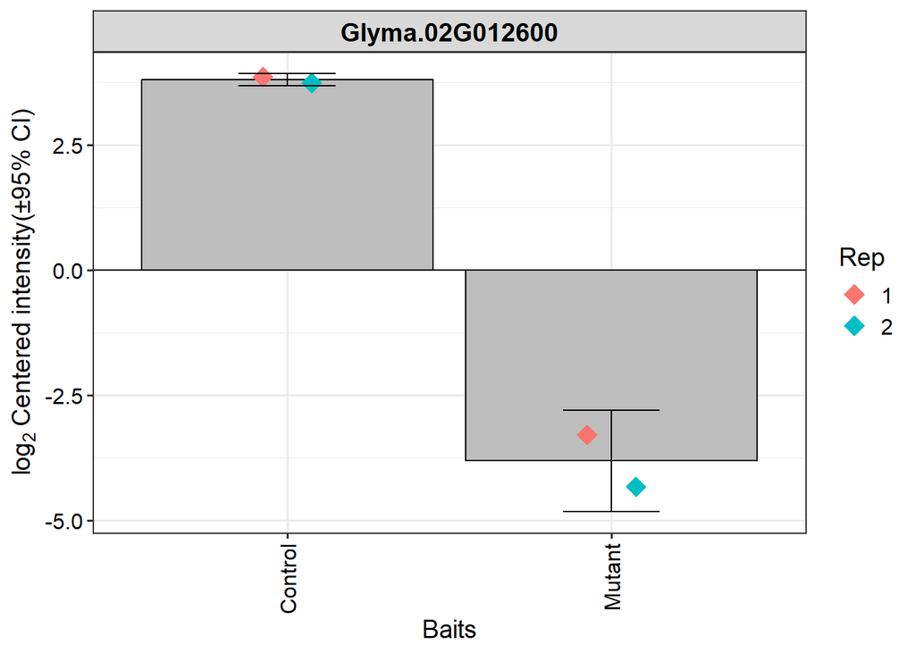

```r
plot_single(dep1,proteins="Glyma.02G012600",type="centered")
```

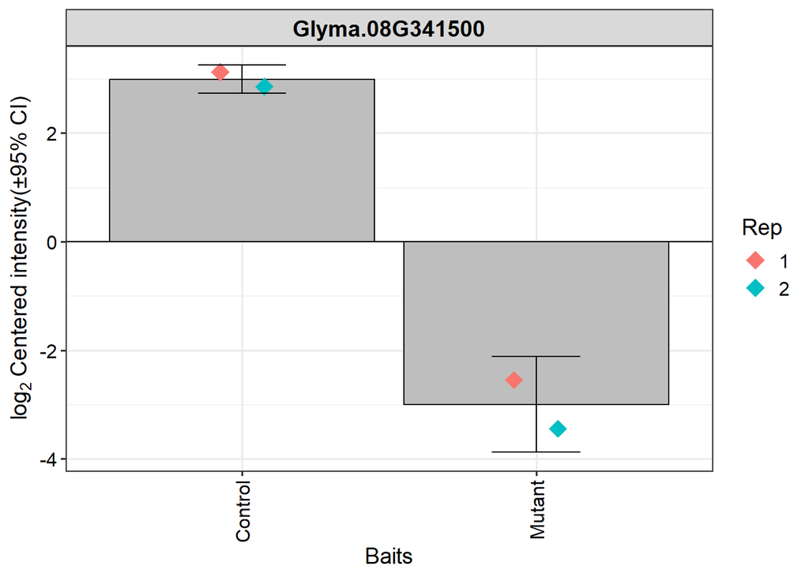

```r
plot_single(dep1,proteins="Glyma.08G341500",type="centered")
```

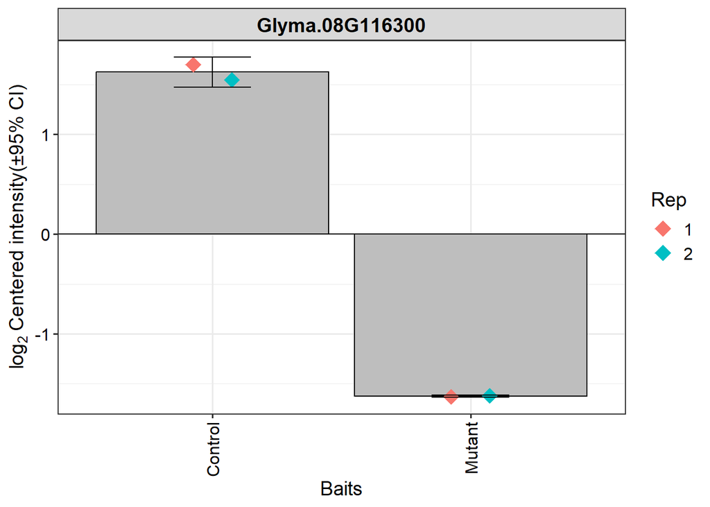

```r
plot_single(dep1,proteins="Glyma.08G116300",type="centered")
```

### 5.1.2 Volcano plot for bert_vs_tn lines

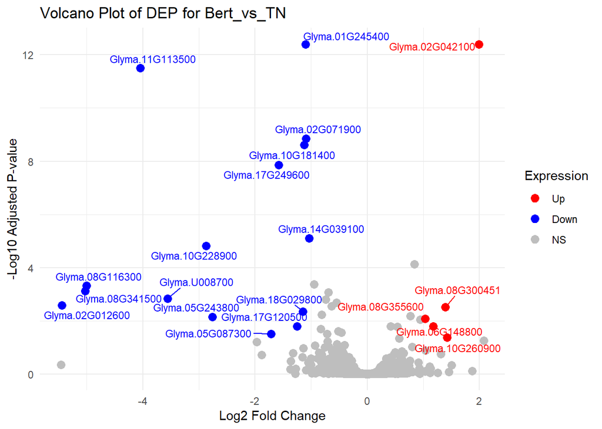

```r
# Volcano plot
pVol2 <- plot_volcano(dep2a,contrast='TN_vs_WT',label_size=2,adjusted = TRUE, add_names = TRUE)

# Extract data from the plot object
volcano_data2 <- pVol2$data

# Add a new column for DE categories based on x and significance
volcano_data2$DE <- with(volcano_data2,
                        ifelse(significant & x > 0, "Up",
                               ifelse(significant & x < 0, "Down", "NS"))
)

# Convert DE column to a factor for consistent plotting
volcano_data2$DE <- factor(volcano_data2$DE, levels = c("Up", "Down", "NS"))

# Create the volcano plot with new DE column
pVol2 <- ggplot(volcano_data2, aes(x = x, y = y, color = DE)) +
  geom_point(size = 3) +
  scale_color_manual(
    values = c(
      "Up" = "red",         # Upregulated proteins
      "Down" = "blue",      # Downregulated proteins
      "NS" = "gray"         # Non-significant proteins
    )
  ) +
  geom_text_repel(
    aes(label = ifelse(DE != "NS", name, "")), # Label significant points (Up or Down)
    max.overlaps = 50,
    size = 3
  ) +
  theme_minimal() +
  labs(
    title = "Volcano Plot of DEP for Bert_vs_TN",
    x = "Log2 Fold Change",
    y = "-Log10 Adjusted P-value",
    color = "Expression"
  )

# Display the volcano plot
print(pVol2)
```

```r
# Save the customized plot
ggsave("prtnquant-volcanoplot_V2_Bert_vs_TN1.png", plot = pVol2, width = 10, height = 8)

###
```

#### 5.1.2.1 Mutant Proteins LE (Glyma.02G012600), KTi3 (Glyma.08G341500), and P34 (Glyma.08G116300) genes in Bert_vs_CrisprTN comparison

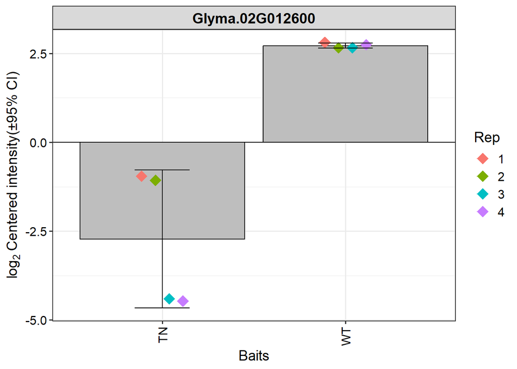

```r
plot_single(dep2a,proteins="Glyma.02G012600",type="centered")
```

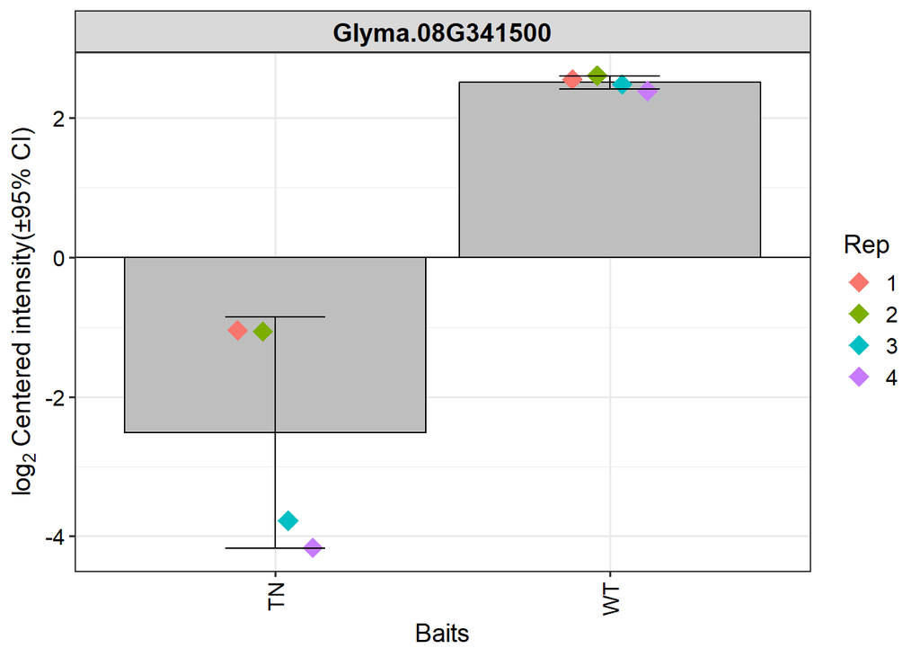

```r
plot_single(dep2a,proteins="Glyma.08G341500",type="centered")
```

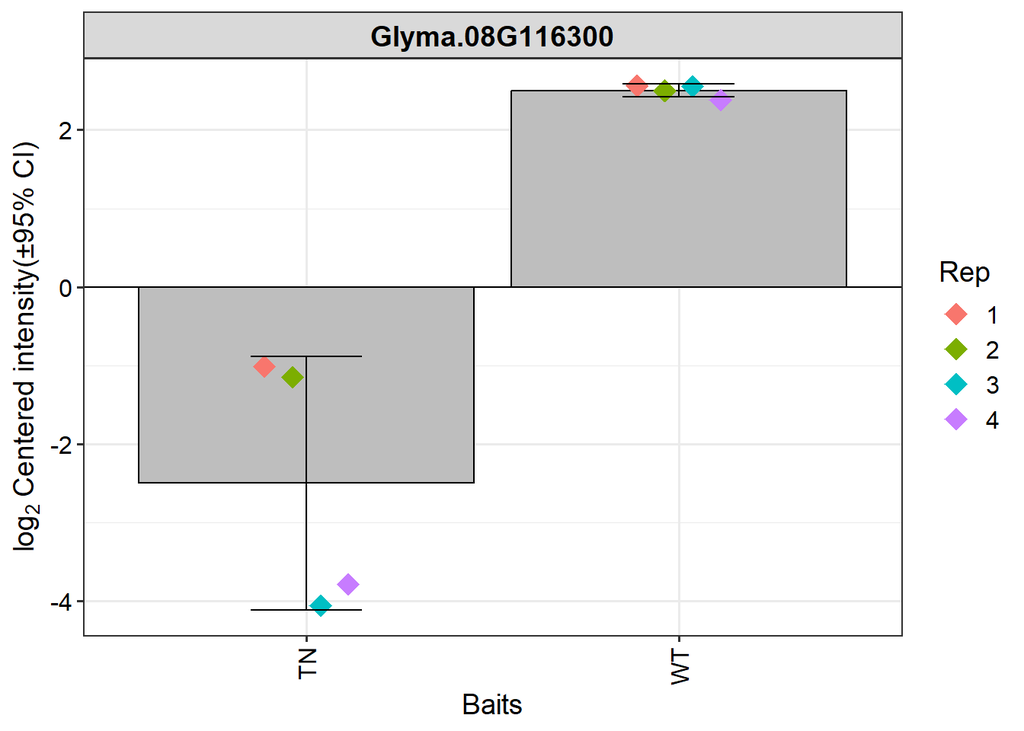

```r
plot_single(dep2a,proteins="Glyma.08G116300",type="centered")
```

### 5.1.3 Volcano plot for bert_vs_tn1 and bert_vs_tn2

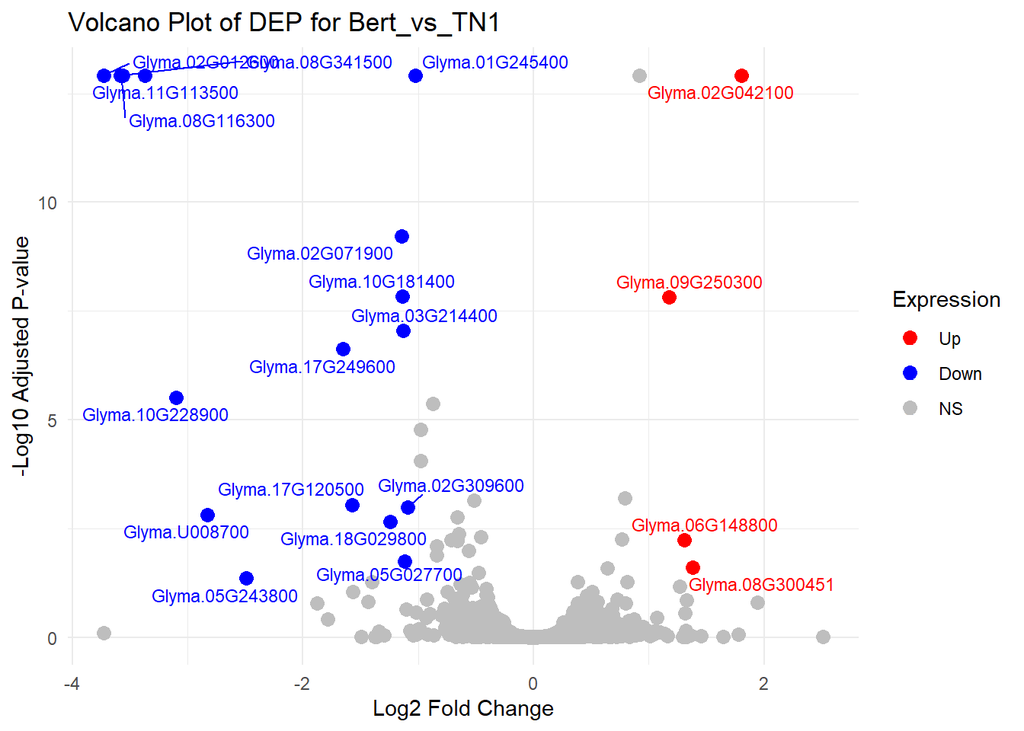

```r
# Volcano plot

pVol2b <- plot_volcano(dep2b,contrast='TN1_vs_WT',label_size=2,adjusted = TRUE, add_names = TRUE)

# Extract data from the plot object
volcano_data2b <- pVol2b$data

# Add a new column for DE categories based on x and significance
volcano_data2b$DE <- with(volcano_data2b,
                        ifelse(significant & x > 0, "Up",
                               ifelse(significant & x < 0, "Down", "NS"))
)

# Convert DE column to a factor for consistent plotting
volcano_data2b$DE <- factor(volcano_data2b$DE, levels = c("Up", "Down", "NS"))

# Create the volcano plot with new DE column
pVol2b <- ggplot(volcano_data2b, aes(x = x, y = y, color = DE)) +
  geom_point(size = 3) +
  scale_color_manual(
    values = c(
      "Up" = "red",         # Upregulated proteins
      "Down" = "blue",      # Downregulated proteins
      "NS" = "gray"         # Non-significant proteins
    )
  ) +
  geom_text_repel(
    aes(label = ifelse(DE != "NS", name, "")), # Label significant points (Up or Down)
    max.overlaps = 50,
    size = 3
  ) +
  theme_minimal() +
  labs(
    title = "Volcano Plot of DEP for Bert_vs_TN1",
    x = "Log2 Fold Change",
    y = "-Log10 Adjusted P-value",
    color = "Expression"
  )

# Display the volcano plot
print(pVol2b)
```

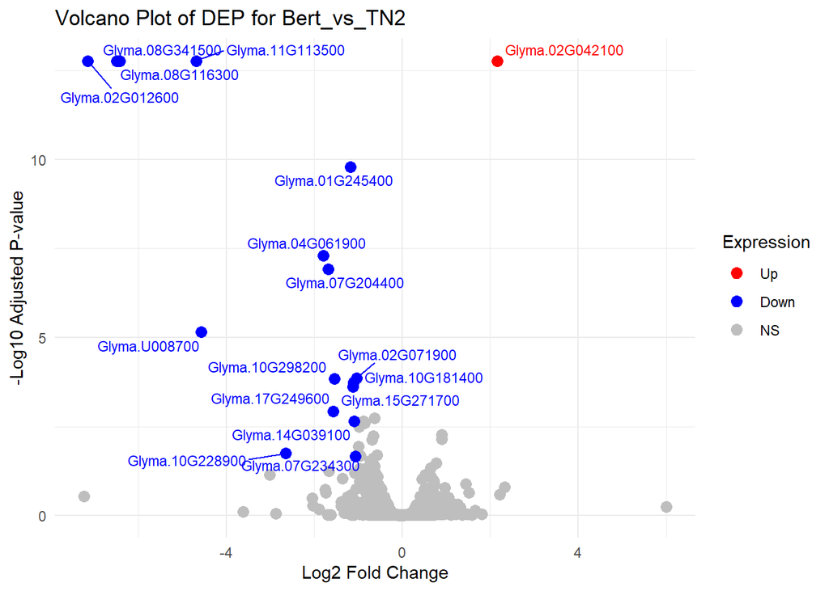

```r
# Save the customized plot
ggsave("prtnquant-volcanoplot_V2_Bert_vs_TN1.png", plot = pVol2b, width = 10, height = 8)

###### ###### ###### ###### ###### ###### ###### ###### ###### ###### ###### ###### ###### ###### ###### ###### ######
###### 'TN2_vs_WT'

pVol2c <- plot_volcano(dep2b,contrast='TN2_vs_WT',label_size=2,adjusted = TRUE, add_names = TRUE)


# Extract data from the plot object
volcano_data2c <- pVol2c$data

# Add a new column for DE categories based on x and significance
volcano_data2c$DE <- with(volcano_data2c,
                        ifelse(significant & x > 0, "Up",
                               ifelse(significant & x < 0, "Down", "NS"))
)

# Convert DE column to a factor for consistent plotting
volcano_data2c$DE <- factor(volcano_data2c$DE, levels = c("Up", "Down", "NS"))

# Create the volcano plot with new DE column
pVol2c <- ggplot(volcano_data2c, aes(x = x, y = y, color = DE)) +
  geom_point(size = 3) +
  scale_color_manual(
    values = c(
      "Up" = "red",         # Upregulated proteins
      "Down" = "blue",      # Downregulated proteins
      "NS" = "gray"         # Non-significant proteins
    )
  ) +
  geom_text_repel(
    aes(label = ifelse(DE != "NS", name, "")), # Label significant points (Up or Down)
    max.overlaps = 50,
    size = 3
  ) +
  theme_minimal() +
  labs(
    title = "Volcano Plot of DEP for Bert_vs_TN2",
    x = "Log2 Fold Change",
    y = "-Log10 Adjusted P-value",
    color = "Expression"
  )



print(pVol2c)
```

```r
# Save the customized plot
ggsave("prtnquant-volcanoplot_V2_Bert_vs_TN2.png", plot = pVol2c, width = 10, height = 8)

###
```

# 6 Conclusion

The proteins Glyma.02G012600, Glyma.08G341500, and Glyma.08G116300, which are the target proteins in the triple null mutant and CRISPR mutant lines, are significantly down-regulated in all three comparisons with their respective controls. Further analysis of other differentially expressed proteins will be performed as part of future studies.